# Drill Down Exercise

US Medicare Payment Data - identifying providers with high payment totals

# Introduction

The US government recently released a data set containing all payments (partially aggregated) made by the Medicare program in 2012. For each health care provider, the billings are grouped into service types, and within each service type group, the total payment and standard deviation of payments are provided.

The data are available [here](http://www.cms.gov/Research-Statistics-Data-and-Systems/Statistics-Trends-and-Reports/Medicare-Provider-Charge-Data/Physician-and-Other-Supplier.html).

The official documentation for the data is [here](http://www.cms.gov/Research-Statistics-Data-and-Systems/Statistics-Trends-and-Reports/Medicare-Provider-Charge-Data/Downloads/Medicare-Physician-and-Other-Supplier-PUF-Methodology.pdf).

One use of these data is to identify providers who receive very high payments from the Medicare program. In some cases this may reflect fraud or waste. Here is a link to a [media article](http://www.miamiherald.com/2014/04/09/4048743/south-florida-opthalmologist-emerges.html) about one such situation.

```r
cms_florida = readr::read_tsv('data/cms_florida.tsv', progress=FALSE)
```

```
Warning: 387 parsing failures.
 row           col               expected actual
1236 line_srvc_cnt no trailing characters     .9
3123 line_srvc_cnt no trailing characters     .8
3848 line_srvc_cnt no trailing characters     .5
3849 line_srvc_cnt no trailing characters     .5
3857 line_srvc_cnt no trailing characters     .5
.... ............. ...................... ......
.See problems(...) for more details.
```

Note the warnings, this is because `line_srvc_cnt`, as a count, should be integer without decimal places. It is not. Whether this is an error (i.e. it is a count and shouldn’t have .5s and .9s) or not (i.e. it shouldn’t be called a count) is uncertain, but we can still proceed for this demo. Note however they have been converted to missing[^1]. You could also reread the data and specify the column as numeric rather than integer as follows.

```r
cms_florida = readr::read_tsv('data/cms_florida.tsv', progress=FALSE, col_types=cols(line_srvc_cnt='n'))
```

We can take a look at the data before getting too far.

```r
str(cms_florida)
```

```
Classes â€˜tbl_dfâ€™, â€˜tblâ€™ and 'data.frame':   686363 obs. of  26 variables:
 $ npi                             : int  1003000522 1003000522 1003000522 1003000522 1003000522 1003000522 1003000522 1003000522 1003000522 1003000522 ...
 $ nppes_provider_last_org_name    : chr  "WEIGAND" "WEIGAND" "WEIGAND" "WEIGAND" ...
 $ nppes_provider_first_name       : chr  "FREDERICK" "FREDERICK" "FREDERICK" "FREDERICK" ...
 $ nppes_provider_mi               : chr  "J" "J" "J" "J" ...
 $ nppes_credentials               : chr  "MD" "MD" "MD" "MD" ...
 $ nppes_provider_gender           : chr  "M" "M" "M" "M" ...
 $ nppes_entity_code               : chr  "I" "I" "I" "I" ...
 $ nppes_provider_street1          : chr  "1565 SAXON BLVD STE 202" "1565 SAXON BLVD STE 202" "1565 SAXON BLVD STE 202" "1565 SAXON BLVD STE 202" ...
 $ nppes_provider_street2          : chr  NA NA NA NA ...
 $ nppes_provider_city             : chr  "DELTONA" "DELTONA" "DELTONA" "DELTONA" ...
 $ nppes_provider_zip              : int  327255836 327255836 327255836 327255836 327255836 327255836 327255836 327255836 327255836 327255836 ...
 $ nppes_provider_state            : chr  "FL" "FL" "FL" "FL" ...
 $ nppes_provider_country          : chr  "US" "US" "US" "US" ...
 $ provider_type                   : chr  "Family Practice" "Family Practice" "Family Practice" "Family Practice" ...
```

[output cut: 17 more lines]

[output not shown]

Each row of the data set is an aggregate of several individual charges. The number of charges that are aggregated is given by line_srvc_cnt. The average of these charges are given by average_Medicare_payment_amt.

The key value of interest here is the total amount of money paid by Medicare to each provider. This is not an explicit variable in the data set, but we can create it by multiplying the average payment by the number of payments, within each record of the data set. We’ll use dplyr’s mutate for this.

```r
cms_florida = cms_florida %>%
  mutate(total_payment = line_srvc_cnt*average_Medicare_payment_amt)
```

Medicare makes payments to both individual providers, and to organizations. Most of the payments are to individuals and it’s not clear that the payment amounts to providers can be directly compared to the payment amounts to individuals. So here we include only the individuals.

```r
cms_florida_ind = filter(cms_florida, nppes_entity_code == 'I')
dim(cms_florida)
```

```
[1] 686363     27
```

```r
dim(cms_florida_ind)
```

```
[1] 655041     27
```

# Payments to individual providers

The overall analysis follows the split-apply-combine model ([Wickham, 2011](https://www.jstatsoft.org/article/view/v040i01/v40i01.pdf)). We split the data by provider, apply a function to aggregate the payments (by summing them), and combine the results into a new data frame.

Our goal is to obtain the total payment for each provider. We first group the data by the provider number, then aggregate within the groups by taking the sum of payment amounts. Finally we sort the result so that the providers with the greatest total payments appear at the top of the list.

```r
totals = cms_florida_ind %>%
  group_by(npi) %>%
  summarise(total_payment = sum(total_payment)) %>%
  arrange(desc(total_payment))
head(totals, 10)
```

```
# A tibble: 10 x 2
          npi total_payment
        <int>         <dbl>
1  1033145487      14661880
2  1922021195      10212086
3  1245298371       8155704
4  1205881976       7619996
5  1821058496       7619358
6  1972550622       7247088
7  1063489383       6692753
8  1881661585       6327853
9  1437117116       6303816
10 1376588582       6295858
```

The functions used here are fairly self-explanatory, but we’ll go through it. You can probably guess what group_by is doing. The summarise function[^2] takes multiple values to create a single value, which is exactly what we need here. The arrange orders the observations by the named variable, while desc puts it in descending order.

Notice that we have not engaged in any explicit looping. This is almost always a bad idea in R, but not because loops are necessarily slower[^3]. One of the key benefits to using dplyr is code that is clear about what it’s doing, and often loops are not. Let’s redo it by adding the names. There are a couple ways we could go about this, but since npi and last name are just different labels for the same entity, grouping by both will give us what we want.

```r
totals = cms_florida_ind %>%
  group_by(npi, nppes_provider_last_org_name) %>%
  summarise(total_payment = sum(total_payment)) %>%
  arrange(desc(total_payment))
head(totals, 10)
```

```
Source: local data frame [10 x 3]
Groups: npi [10]

          npi nppes_provider_last_org_name total_payment
        <int>                        <chr>         <dbl>
1  1033145487                        QAMAR      14661880
2  1922021195                        EATON      10212086
3  1245298371                       MELGEN       8155704
4  1205881976                        BAUDO       7619996
5  1821058496                     MALHOTRA       7619358
6  1972550622                     WAFAPOOR       7247088
7  1063489383                        GUPTA       6692753
8  1881661585                        MYERS       6327853
9  1437117116                         TRAN       6303816
10 1376588582                          PAL       6295858
```

One way to visualize the distribution of payments is to make a quantile plot, which is a plot of the sorted data against the index. We’ll use ggplot2.

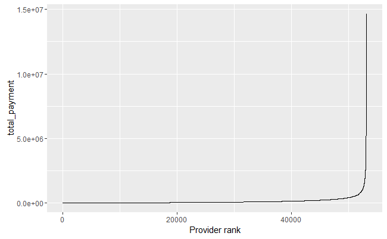

```r
library(ggplot2)
totals %>%
  ggplot(aes(x=rank(total_payment), y=total_payment)) +
  geom_line() +
  xlab('Provider rank')
```

Another familiar way to view a simple collection of numbers is using a histogram or density plot.

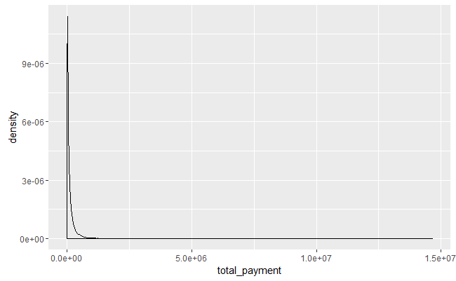

```r
qplot(x=total_payment, data=totals, geom='density')
```

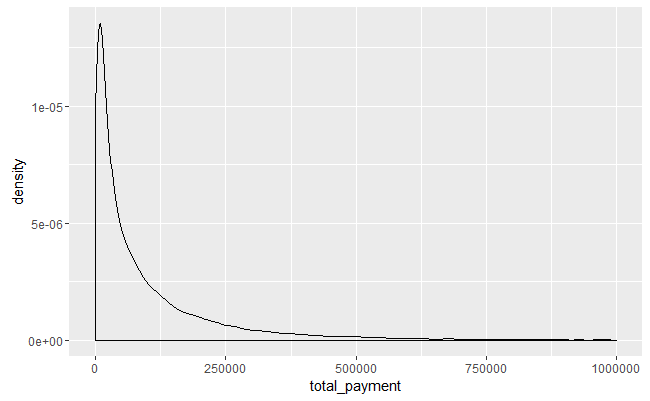

```r
totals %>%
  filter(total_payment<1e6) %>%
  qplot(x=total_payment, geom='density', data=.)
```

Note that the ‘.’ represents whatever was present before the last pipe. It’s typically not necessary, but in this case it was. As an alternative, one could have piped with `%$%` from magrittr and ignored the data argument, as `%$%` throws the names of its contents forward to the next function.

Exercises

- Determine the maximum total payment among providers within each zip code, then plot it as a histogram or quantile plot.
- Determine the maximum total payment among providers of each provider type, then plot it as a histogram or quantile plot.
[^1]: Which is appropriate in my opinion if they are supposed to be counts.
[^2]: dplyr accepts both American and British (New Zealand) English.
[^3]: Using things like apply, lapply and so forth will not typically provide a speed gain over an explicit loop, just some code efficiency, and because you’ll have written a function in order to use them, you’ll probably have more generalizability and/or reproducibility also. However, almost any loop can potentially be written in a faster manner. Every loop that doesn’t require a sequential operation *can* be made faster.